# Risk Factor Analysis

## Outcome Variable

**Outcome Variable:** co_occurence

## Predictor Variables

**Intervention Variable:** ever_swasted06

**Adjustment Set:**

- sex
- arm
- enstunt
- month
- brthmon
- hhwealth_quart
- W_birthwt
- W_birthlen
- W_mage
- W_mhtcm
- W_meducyrs
- W_feducyrs
- delta_month
- delta_brthmon
- delta_hhwealth_quart
- delta_W_birthwt
- delta_W_birthlen
- delta_W_mage
- delta_W_mhtcm
- delta_W_meducyrs
- delta_W_feducyrs

## Stratifying Variables

The analysis was stratified on these variable(s):

- studyid
- country

## Data Summary

| studyid | country | ever_swasted06 | co_occurence | n_cell | n |
| --- | --- | --- | --- | --- | --- |
| ki0047075b-MAL-ED | BANGLADESH | 0 | 0 | 194 | 221 |
| ki0047075b-MAL-ED | BANGLADESH | 0 | 1 | 12 | 221 |
| ki0047075b-MAL-ED | BANGLADESH | 1 | 0 | 13 | 221 |
| ki0047075b-MAL-ED | BANGLADESH | 1 | 1 | 2 | 221 |
| ki0047075b-MAL-ED | BRAZIL | 0 | 0 | 178 | 180 |
| ki0047075b-MAL-ED | BRAZIL | 0 | 1 | 1 | 180 |
| ki0047075b-MAL-ED | BRAZIL | 1 | 0 | 1 | 180 |
| ki0047075b-MAL-ED | BRAZIL | 1 | 1 | 0 | 180 |
| ki0047075b-MAL-ED | INDIA | 0 | 0 | 196 | 228 |
| ki0047075b-MAL-ED | INDIA | 0 | 1 | 12 | 228 |
| ki0047075b-MAL-ED | INDIA | 1 | 0 | 15 | 228 |
| ki0047075b-MAL-ED | INDIA | 1 | 1 | 5 | 228 |
| ki0047075b-MAL-ED | NEPAL | 0 | 0 | 218 | 229 |
| ki0047075b-MAL-ED | NEPAL | 0 | 1 | 4 | 229 |
| ki0047075b-MAL-ED | NEPAL | 1 | 0 | 7 | 229 |
| ki0047075b-MAL-ED | NEPAL | 1 | 1 | 0 | 229 |
| ki0047075b-MAL-ED | PERU | 0 | 0 | 215 | 222 |
| ki0047075b-MAL-ED | PERU | 0 | 1 | 6 | 222 |
| ki0047075b-MAL-ED | PERU | 1 | 0 | 1 | 222 |
| ki0047075b-MAL-ED | PERU | 1 | 1 | 0 | 222 |
| ki0047075b-MAL-ED | SOUTH AFRICA | 0 | 0 | 232 | 241 |
| ki0047075b-MAL-ED | SOUTH AFRICA | 0 | 1 | 3 | 241 |
| ki0047075b-MAL-ED | SOUTH AFRICA | 1 | 0 | 5 | 241 |
| ki0047075b-MAL-ED | SOUTH AFRICA | 1 | 1 | 1 | 241 |
| ki0047075b-MAL-ED | TANZANIA, UNITED REPUBLIC OF | 0 | 0 | 220 | 225 |
| ki0047075b-MAL-ED | TANZANIA, UNITED REPUBLIC OF | 0 | 1 | 1 | 225 |
| ki0047075b-MAL-ED | TANZANIA, UNITED REPUBLIC OF | 1 | 0 | 4 | 225 |
| ki0047075b-MAL-ED | TANZANIA, UNITED REPUBLIC OF | 1 | 1 | 0 | 225 |
| ki1000108-CMC-V-BCS-2002 | INDIA | 0 | 0 | 284 | 366 |
| ki1000108-CMC-V-BCS-2002 | INDIA | 0 | 1 | 11 | 366 |

[output cut: 90 more lines]

The following strata were considered:

- studyid: ki0047075b-MAL-ED, country: BANGLADESH
- studyid: ki0047075b-MAL-ED, country: BRAZIL
- studyid: ki0047075b-MAL-ED, country: INDIA
- studyid: ki0047075b-MAL-ED, country: NEPAL
- studyid: ki0047075b-MAL-ED, country: PERU
- studyid: ki0047075b-MAL-ED, country: SOUTH AFRICA
- studyid: ki0047075b-MAL-ED, country: TANZANIA, UNITED REPUBLIC OF
- studyid: ki1000108-CMC-V-BCS-2002, country: INDIA
- studyid: ki1000108-IRC, country: INDIA
- studyid: ki1000109-EE, country: PAKISTAN
- studyid: ki1000109-ResPak, country: PAKISTAN
- studyid: ki1000304b-SAS-CompFeed, country: INDIA
- studyid: ki1000304b-SAS-FoodSuppl, country: INDIA
- studyid: ki1017093-NIH-Birth, country: BANGLADESH
- studyid: ki1017093b-PROVIDE, country: BANGLADESH
- studyid: ki1017093c-NIH-Crypto, country: BANGLADESH
- studyid: ki1066203-TanzaniaChild2, country: TANZANIA, UNITED REPUBLIC OF
- studyid: ki1101329-Keneba, country: GAMBIA
- studyid: ki1113344-GMS-Nepal, country: NEPAL
- studyid: ki1114097-CMIN, country: BANGLADESH
- studyid: ki1114097-CMIN, country: BRAZIL
- studyid: ki1114097-CMIN, country: GUINEA-BISSAU
- studyid: ki1114097-CMIN, country: PERU
- studyid: ki1114097-CONTENT, country: PERU
- studyid: ki1119695-PROBIT, country: BELARUS
- studyid: ki1126311-ZVITAMBO, country: ZIMBABWE
- studyid: ki1135781-COHORTS, country: GUATEMALA
- studyid: ki1135781-COHORTS, country: PHILIPPINES
- studyid: ki1148112-LCNI-5, country: MALAWI
- studyid: kiGH5241-JiVitA-4, country: BANGLADESH

### Dropped Strata

Some strata were dropped due to rare outcomes:

- studyid: ki0047075b-MAL-ED, country: BANGLADESH
- studyid: ki0047075b-MAL-ED, country: BRAZIL
- studyid: ki0047075b-MAL-ED, country: NEPAL
- studyid: ki0047075b-MAL-ED, country: PERU
- studyid: ki0047075b-MAL-ED, country: SOUTH AFRICA
- studyid: ki0047075b-MAL-ED, country: TANZANIA, UNITED REPUBLIC OF
- studyid: ki1000109-ResPak, country: PAKISTAN
- studyid: ki1017093b-PROVIDE, country: BANGLADESH
- studyid: ki1017093c-NIH-Crypto, country: BANGLADESH
- studyid: ki1066203-TanzaniaChild2, country: TANZANIA, UNITED REPUBLIC OF
- studyid: ki1114097-CMIN, country: BANGLADESH
- studyid: ki1114097-CMIN, country: BRAZIL
- studyid: ki1114097-CMIN, country: GUINEA-BISSAU
- studyid: ki1114097-CMIN, country: PERU
- studyid: ki1114097-CONTENT, country: PERU
- studyid: ki1119695-PROBIT, country: BELARUS
- studyid: ki1135781-COHORTS, country: GUATEMALA
- studyid: ki1148112-LCNI-5, country: MALAWI

## Methods Detail

We’re interested in the causal parameters $E[Y_a]$ for all values of $a \in \mathcal{A}$. These parameters represent the mean outcome if, possibly contrary to fact, we intervened to set all units to have $A=a$. Under the randomization and positivity assumptions, these are identified by the statistical parameters $\psi_a=E_W[E_{Y|A,W}(Y|A=a,W)]$. In addition, we’re interested in the mean of $Y$, $E[Y]$ under no intervention (the observed mean). We will estimate these parameters by using SuperLearner to fit the relevant likelihood factors – $E_{Y|A,W}(Y|A=a,W)$ and $p(A=a|W)$, and then updating our likelihood fit using a joint TMLE.

For unadjusted analyses ($W=\{\}$), initial likelihoods were estimated using Lrnr_glm to estimate the simple $E(Y|A)$ and Lrnr_mean to estimate $p(A)$. For adjusted analyses, a small library containing Lrnr_glmnet, Lrnr_xgboost, and Lrnr_mean was used.

Having estimated these parameters, we will then use the delta method to estimate relative risks and attributable risks relative to a prespecified baseline level of $A$.

# Results Detail

## Results Plots

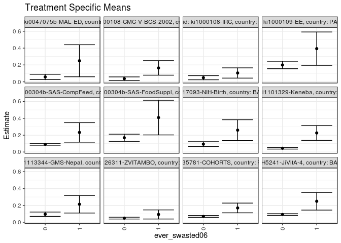

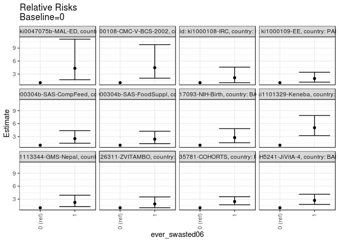

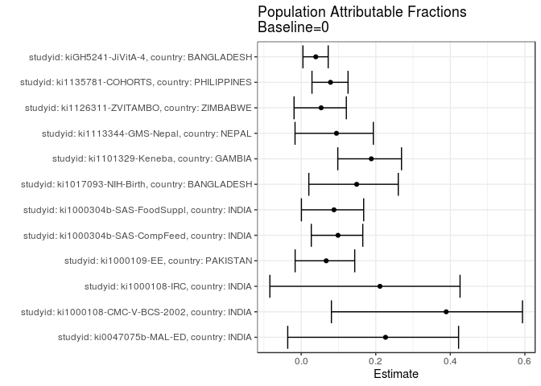

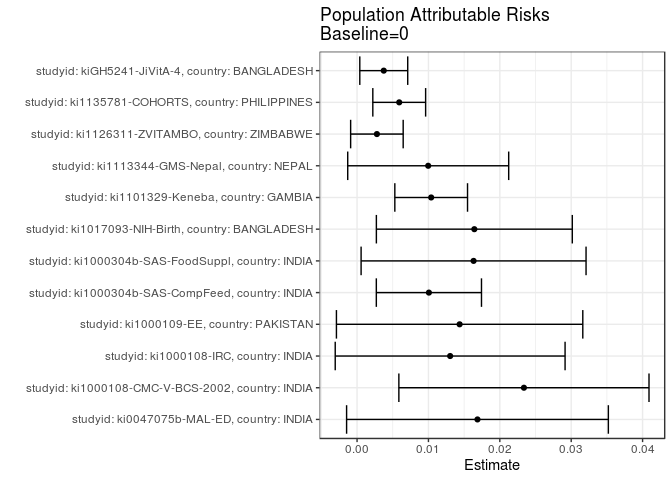

## Results Table

### Parameter: TSM

| studyid | country | intervention_level | baseline_level | estimate | ci_lower | ci_upper |
| --- | --- | --- | --- | --- | --- | --- |
| ki0047075b-MAL-ED | INDIA | 0 | NA | 0.0576923 | 0.0259363 | 0.0894483 |
| ki0047075b-MAL-ED | INDIA | 1 | NA | 0.2500000 | 0.0598098 | 0.4401902 |
| ki1000108-CMC-V-BCS-2002 | INDIA | 0 | NA | 0.0367313 | 0.0153187 | 0.0581440 |
| ki1000108-CMC-V-BCS-2002 | INDIA | 1 | NA | 0.1644991 | 0.0785945 | 0.2504036 |
| ki1000108-IRC | INDIA | 0 | NA | 0.0486873 | 0.0241581 | 0.0732164 |
| ki1000108-IRC | INDIA | 1 | NA | 0.1046429 | 0.0437125 | 0.1655734 |
| ki1000109-EE | PAKISTAN | 0 | NA | 0.1999188 | 0.1557480 | 0.2440896 |
| ki1000109-EE | PAKISTAN | 1 | NA | 0.3934919 | 0.1953949 | 0.5915889 |
| ki1000304b-SAS-CompFeed | INDIA | 0 | NA | 0.0918456 | 0.0804799 | 0.1032113 |
| ki1000304b-SAS-CompFeed | INDIA | 1 | NA | 0.2327006 | 0.1170186 | 0.3483826 |
| ki1000304b-SAS-FoodSuppl | INDIA | 0 | NA | 0.1694352 | 0.1269902 | 0.2118802 |
| ki1000304b-SAS-FoodSuppl | INDIA | 1 | NA | 0.4090909 | 0.2033217 | 0.6148601 |
| ki1017093-NIH-Birth | BANGLADESH | 0 | NA | 0.0939603 | 0.0658464 | 0.1220741 |
| ki1017093-NIH-Birth | BANGLADESH | 1 | NA | 0.2597372 | 0.1357608 | 0.3837137 |
| ki1101329-Keneba | GAMBIA | 0 | NA | 0.0448241 | 0.0348893 | 0.0547590 |
| ki1101329-Keneba | GAMBIA | 1 | NA | 0.2265717 | 0.1389023 | 0.3142411 |
| ki1113344-GMS-Nepal | NEPAL | 0 | NA | 0.0954874 | 0.0695614 | 0.1214134 |
| ki1113344-GMS-Nepal | NEPAL | 1 | NA | 0.2137537 | 0.1097390 | 0.3177685 |
| ki1126311-ZVITAMBO | ZIMBABWE | 0 | NA | 0.0491829 | 0.0383925 | 0.0599732 |
| ki1126311-ZVITAMBO | ZIMBABWE | 1 | NA | 0.0926451 | 0.0385947 | 0.1466956 |
| ki1135781-COHORTS | PHILIPPINES | 0 | NA | 0.0692845 | 0.0589476 | 0.0796213 |
| ki1135781-COHORTS | PHILIPPINES | 1 | NA | 0.1698092 | 0.1119551 | 0.2276633 |
| kiGH5241-JiVitA-4 | BANGLADESH | 0 | NA | 0.0919082 | 0.0824927 | 0.1013238 |
| kiGH5241-JiVitA-4 | BANGLADESH | 1 | NA | 0.2492056 | 0.1447043 | 0.3537070 |

### Parameter: E(Y)

| studyid | country | intervention_level | baseline_level | estimate | ci_lower | ci_upper |
| --- | --- | --- | --- | --- | --- | --- |
| ki0047075b-MAL-ED | INDIA | NA | NA | 0.0745614 | 0.0403897 | 0.1087331 |
| ki1000108-CMC-V-BCS-2002 | INDIA | NA | NA | 0.0601093 | 0.0357249 | 0.0844936 |
| ki1000108-IRC | INDIA | NA | NA | 0.0617284 | 0.0382610 | 0.0851958 |
| ki1000109-EE | PAKISTAN | NA | NA | 0.2142857 | 0.1712366 | 0.2573348 |
| ki1000304b-SAS-CompFeed | INDIA | NA | NA | 0.1019108 | 0.0902026 | 0.1136190 |
| ki1000304b-SAS-FoodSuppl | INDIA | NA | NA | 0.1857585 | 0.1432798 | 0.2282372 |
| ki1017093-NIH-Birth | BANGLADESH | NA | NA | 0.1103896 | 0.0817833 | 0.1389959 |
| ki1101329-Keneba | GAMBIA | NA | NA | 0.0552077 | 0.0445257 | 0.0658898 |
| ki1113344-GMS-Nepal | NEPAL | NA | NA | 0.1054545 | 0.0797627 | 0.1311464 |
| ki1126311-ZVITAMBO | ZIMBABWE | NA | NA | 0.0519637 | 0.0412672 | 0.0626603 |
| ki1135781-COHORTS | PHILIPPINES | NA | NA | 0.0751910 | 0.0648251 | 0.0855569 |
| kiGH5241-JiVitA-4 | BANGLADESH | NA | NA | 0.0956483 | 0.0855904 | 0.1057063 |

### Parameter: RR

| studyid | country | intervention_level | baseline_level | estimate | ci_lower | ci_upper |
| --- | --- | --- | --- | --- | --- | --- |
| ki0047075b-MAL-ED | INDIA | 0 | 0 | 1.000000 | 1.000000 | 1.000000 |
| ki0047075b-MAL-ED | INDIA | 1 | 0 | 4.333333 | 1.694398 | 11.082272 |
| ki1000108-CMC-V-BCS-2002 | INDIA | 0 | 0 | 1.000000 | 1.000000 | 1.000000 |
| ki1000108-CMC-V-BCS-2002 | INDIA | 1 | 0 | 4.478438 | 2.045730 | 9.804037 |
| ki1000108-IRC | INDIA | 0 | 0 | 1.000000 | 1.000000 | 1.000000 |
| ki1000108-IRC | INDIA | 1 | 0 | 2.149287 | 1.003281 | 4.604326 |
| ki1000109-EE | PAKISTAN | 0 | 0 | 1.000000 | 1.000000 | 1.000000 |
| ki1000109-EE | PAKISTAN | 1 | 0 | 1.968258 | 1.133837 | 3.416752 |
| ki1000304b-SAS-CompFeed | INDIA | 0 | 0 | 1.000000 | 1.000000 | 1.000000 |
| ki1000304b-SAS-CompFeed | INDIA | 1 | 0 | 2.533606 | 1.467524 | 4.374144 |
| ki1000304b-SAS-FoodSuppl | INDIA | 0 | 0 | 1.000000 | 1.000000 | 1.000000 |
| ki1000304b-SAS-FoodSuppl | INDIA | 1 | 0 | 2.414439 | 1.376503 | 4.235018 |
| ki1017093-NIH-Birth | BANGLADESH | 0 | 0 | 1.000000 | 1.000000 | 1.000000 |
| ki1017093-NIH-Birth | BANGLADESH | 1 | 0 | 2.764330 | 1.576234 | 4.847960 |
| ki1101329-Keneba | GAMBIA | 0 | 0 | 1.000000 | 1.000000 | 1.000000 |
| ki1101329-Keneba | GAMBIA | 1 | 0 | 5.054683 | 3.237929 | 7.890790 |
| ki1113344-GMS-Nepal | NEPAL | 0 | 0 | 1.000000 | 1.000000 | 1.000000 |
| ki1113344-GMS-Nepal | NEPAL | 1 | 0 | 2.238555 | 1.281635 | 3.909947 |
| ki1126311-ZVITAMBO | ZIMBABWE | 0 | 0 | 1.000000 | 1.000000 | 1.000000 |
| ki1126311-ZVITAMBO | ZIMBABWE | 1 | 0 | 1.883687 | 1.009773 | 3.513934 |
| ki1135781-COHORTS | PHILIPPINES | 0 | 0 | 1.000000 | 1.000000 | 1.000000 |
| ki1135781-COHORTS | PHILIPPINES | 1 | 0 | 2.450899 | 1.690252 | 3.553852 |
| kiGH5241-JiVitA-4 | BANGLADESH | 0 | 0 | 1.000000 | 1.000000 | 1.000000 |
| kiGH5241-JiVitA-4 | BANGLADESH | 1 | 0 | 2.711462 | 1.778881 | 4.132950 |

### Parameter: PAR

| studyid | country | intervention_level | baseline_level | estimate | ci_lower | ci_upper |
| --- | --- | --- | --- | --- | --- | --- |
| ki0047075b-MAL-ED | INDIA | 0 | NA | 0.0168691 | -0.0014660 | 0.0352042 |
| ki1000108-CMC-V-BCS-2002 | INDIA | 0 | NA | 0.0233779 | 0.0058565 | 0.0408994 |
| ki1000108-IRC | INDIA | 0 | NA | 0.0130411 | -0.0030589 | 0.0291411 |
| ki1000109-EE | PAKISTAN | 0 | NA | 0.0143669 | -0.0028899 | 0.0316237 |
| ki1000304b-SAS-CompFeed | INDIA | 0 | NA | 0.0100652 | 0.0026992 | 0.0174312 |
| ki1000304b-SAS-FoodSuppl | INDIA | 0 | NA | 0.0163233 | 0.0005665 | 0.0320801 |
| ki1017093-NIH-Birth | BANGLADESH | 0 | NA | 0.0164293 | 0.0027056 | 0.0301531 |
| ki1101329-Keneba | GAMBIA | 0 | NA | 0.0103836 | 0.0052914 | 0.0154758 |
| ki1113344-GMS-Nepal | NEPAL | 0 | NA | 0.0099672 | -0.0013084 | 0.0212427 |
| ki1126311-ZVITAMBO | ZIMBABWE | 0 | NA | 0.0027809 | -0.0008995 | 0.0064613 |
| ki1135781-COHORTS | PHILIPPINES | 0 | NA | 0.0059065 | 0.0022075 | 0.0096056 |
| kiGH5241-JiVitA-4 | BANGLADESH | 0 | NA | 0.0037401 | 0.0003830 | 0.0070972 |

### Parameter: PAF

| studyid | country | intervention_level | baseline_level | estimate | ci_lower | ci_upper |
| --- | --- | --- | --- | --- | --- | --- |
| ki0047075b-MAL-ED | INDIA | 0 | NA | 0.2262443 | -0.0361734 | 0.4222031 |
| ki1000108-CMC-V-BCS-2002 | INDIA | 0 | NA | 0.3889240 | 0.0810442 | 0.5936541 |
| ki1000108-IRC | INDIA | 0 | NA | 0.2112660 | -0.0840781 | 0.4261471 |
| ki1000109-EE | PAKISTAN | 0 | NA | 0.0670455 | -0.0163132 | 0.1435670 |
| ki1000304b-SAS-CompFeed | INDIA | 0 | NA | 0.0987651 | 0.0270485 | 0.1651955 |
| ki1000304b-SAS-FoodSuppl | INDIA | 0 | NA | 0.0878738 | 0.0005171 | 0.1675953 |
| ki1017093-NIH-Birth | BANGLADESH | 0 | NA | 0.1488303 | 0.0204315 | 0.2603990 |
| ki1101329-Keneba | GAMBIA | 0 | NA | 0.1880825 | 0.0981070 | 0.2690819 |
| ki1113344-GMS-Nepal | NEPAL | 0 | NA | 0.0945161 | -0.0165998 | 0.1934870 |
| ki1126311-ZVITAMBO | ZIMBABWE | 0 | NA | 0.0535157 | -0.0192090 | 0.1210513 |
| ki1135781-COHORTS | PHILIPPINES | 0 | NA | 0.0785539 | 0.0288986 | 0.1256701 |
| kiGH5241-JiVitA-4 | BANGLADESH | 0 | NA | 0.0391029 | 0.0046293 | 0.0723825 |